# 4)Eigendecomposition+SVD+PCA

### 7.2) Choose the encoding matrix D

- Purpose of the PCA is to change the coordinate system in order to maximize the variance along the first dimensions of the projected space.
- Maximizing the variance corresponds to minimizing the error of the reconstruction.
- Since we will use the same matrix **D** to decode all the points, we can no longer consider the points in isolation. Instead, we must minimize the Frobenius norm of the matrixof errors computed over all dimensions and all points:
- Forbeus Norm Formula : $$\left \| A \right \|_{F} = \sqrt{\sum_{i,j}A^{2}_{i,j}}$$
- It is like if you unroll the matrix to end up with a one dimensional vector and that you take the $L^{2}$ norm of this vector.
- Using This formula we get :

$$D^{*} = argmin_{D}\sqrt{\sum_{i,j}\left ( x_{j}^{\left ( i \right )} -r\left ( x ^{\left ( i \right )}\right )_{j}\right )^{2}}$$

- **Constraint:** $D^{T}D=I_{l}$
- We will start to find only the first principal component (PC). For that reason, we will have l=1. So the matrix D will have the shape (n×1). Since it is a column vector, we can call it **d**

$$d^{*} = argmin_{d}\sum_{i}\left \| x^{\left ( i \right )}-r(x^{\left ( i \right )}) \right \|_{2}^{2}$$

$$r(x)=DD^{T}x$$

- Since we are looking only for the first PC:

$$r(x) = dd^{T}x$$

- Plugging this r(x) into the equation, we get:

$$ d^{*} = argmin_{d}\sum_{i}\left \| x^{\left ( i \right )}-dd^{T}x^\left ( i \right ) \right \|^{2}_{2} $$

$$‖d‖_{2} = 1$$

- We want $x(i)^{T}$ instead of $x^{(i)}$ in our expression of $d^{∗}$ . So taking transpose we get :

$$d^{*} = argmin_{d}\sum_{i}\left \| \left ( x^{\left ( i \right )} -dd^{T}x^{\left ( i \right )} \right )^{T} \right \|_{2}^{2}$$

$$ = argmin_{d}\sum_{i}\left \| (x^{(i)})^{T} - (x^{(i)})^{T}dd^{T} \right\| _{2}^{2} $$

$$d^{*} = argmin_{d}\left \| X - Xdd^{T} \right \|_{F}^{2}$$

$$ d^{T}d = 1$$

- Using the Trace Operator to simplify the above equation

$$||A||_{F} = \sqrt{Tr(AA^{T})} $$

- Now using this in our equation for $d^{*}$, we get :

$$ d^{∗} = argmin_{d}Tr((X−Xdd^{T})(X−Xdd^{T})^{T}) $$

- Now $Tr(AB) = Tr(BA)$. Using this we get :

$$ d^{∗} = argmin_{d}Tr((X−Xdd^{T})^{T}(X−Xdd^{T})) $$

$$ = argmin_{d}Tr((X^{T}−(Xdd^{T})^{T})(X−Xdd^{T})) $$

$$ (Xdd^{T})^{T} = (d^{T})^{T}d^{T}X^{T}=dd^{T}X^{T} $$

- Plugging this into the equation, we will get :

$$ d^{∗} = argmin_{d}Tr(X^{T}−dd^{T}X^{T})(X−Xdd^{T})) $$

$$ = argmin_{d}Tr(X^{T}X−X^{T}Xdd^{T}−dd^{T}X^{T}X+dd^{T}X^{T}Xdd^{T}) $$

$$ =argmin_{d}Tr(X^{T}X)−Tr(X^{T}Xdd^{T})−Tr(dd^{T}X^{T}X)+Tr(dd^{T}X^{T}Xdd^{T}) $$

- We need to minimize for d, so we can remove all the terms that do not contain d :

$$ d^{∗}=argmin_{d}−Tr(X^{T}Xdd^{T})−Tr(dd^{T}X^{T}X)+Tr(dd^{T}X^{T}Xdd^{T}) $$

- Due to cyclic property of Trace : $ Tr(X^{T}Xdd^{T})=Tr(dd^{T}X^{T}X) $

$$ d^{∗}=argmin_{d}−2Tr(X^{T}Xdd^{T})+Tr(dd^{T}X^{T}Xdd^{T}) $$

$$ d^{∗}=argmin_{d}−2Tr(X^{T}Xdd^{T})+Tr(X^{T}Xdd^{T}dd^{T}) $$

- Now we know $ d^{T}d=1$

$$ d^{∗} = argmin_{d}−2Tr(X^{T}Xdd^{T})+Tr(X^{T}Xdd^{T}) $$

- subject to $d^{T}d=1$

$$ = argmin_{d}−Tr(X^{T}Xdd^{T}) $$

- subject to $d^{T}d=1$

$$ argmax_{d}Tr(X^{T}Xdd^{T}) $$

- subject to $d^{T}d=1$

$$ d^{∗} = argmax_{d}Tr(d^{T}X^{T}Xd) $$

- subject to $d^{T}d=1$
- We can use Eigen Decomposition to solve the equation. The optimal d is given by the the eigen vector of $X^{T}X$ corresponding to largest Eigen value.
- The matrix $X^{T}X$ is called the Covariance Matrix when we center the data around 0.
- The covariance matrix is a n by n matrix. Its diagonal is the variance of the corresponding dimensions.
- Other cells are the Covariance between the two corresponding dimensions which tells us the amount of redundancy.
- This means that the largest covariance we have between two dimensions the more redundancy exists between these dimensions. That means if variance is high, then we get small errors.
- To maximize the variance and minimize the covariance (in order to decorrelate the dimensions) means that the ideal covariance matrix is a diagonal matrix (non-zero values in the diagonal only).
- The diagonalization of the covariance matrix will give us the optimal solution.

```python
#Create a Random Array:
np.random.seed(123)
x = 5*np.random.rand(100)
y = 2*x + 1 + np.random.randn(100)

x = x.reshape(100, 1)
y = y.reshape(100, 1)

X = np.hstack([x, y])
X.shape
```

```
(100, 2)
```

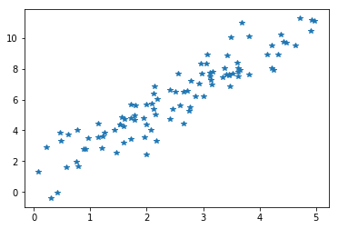

```python
#Let's plot the two dimensions of x :
plt.plot(X[:,0], X[:,1], '*')
plt.show()
```

- When data is highly correlated, then dimensions are redundant and we can predict one from another without losing much information.

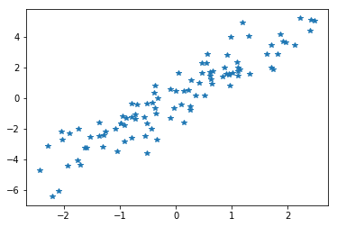

```python
# Now we will center the data :

X_center =X - np.mean(X, axis = 0)

plt.plot(X_center[:,0], X_center[:,1], '*')
plt.show()
```

- We need to find the Principal Component now :
- Since this is 2-d we can have only 2 components. So we need to find d which maximizes the function :

$$ d^{∗} = argmax_{d}Tr(d^{T}X^{T}Xd) $$

- To find d we need to calculate the eigenvectors of $X^{T}X$

```python
eigVals,  eigVecs = np.linalg.eig(X_center.T.dot(X_center))
print("Eigen Vectors = \n", eigVecs)
print("Eigen Values = \n",np.diag(eigVals))
```

```
Eigen Vectors =
 [[-0.91116273 -0.41204669]
 [ 0.41204669 -0.91116273]]
Eigen Values =
 [[ 18.04730409   0.        ]
 [  0.         798.35242844]]
```

- The eigen vector associated with the larger eigenvalue tells us the direction associated with the larger variance in our data.

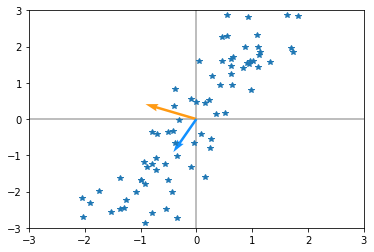

```python
orange = '#FF9A13'
blue = '#1190FF'
plotVectors(eigVecs.T, [orange, blue])
plt.plot(X_center[:,0], X_center[:,1], '*')
plt.xlim(-3, 3)
plt.ylim(-3, 3)
plt.show()
```

- If we project the data points on the line corresponding to the blue vector direction, we will end up with the largest variance. This vector has the direction that maximizes variance of projected data.
- Now that we have found the matrix d we will use the encoding function to rotate the data. **The goal of the rotation is to end up with a new coordinate system where data is uncorrelated and thus where the basis axes gather all the variance. It is then possible to keep only few axes: this is the purpose of dimensionality reduction.**
- Encoding function $c=D^{T}x$ . D is the matrix containing the eigenvectors

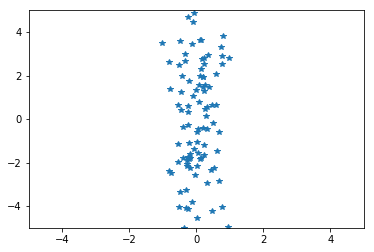

```python
X_new = eigVecs.T.dot(X_center.T)
plt.plot(X_new[0, :], X_new[1, :], '*')
plt.xlim(-5, 5)
plt.ylim(-5, 5)
plt.show()
```

- The rotation transformed our dataset that have now the more variance on one of the basis axis.

**What if we don't center the data????**

```python
eigVals,  eigVecs = np.linalg.eig(X.T.dot(X))
print("Eigen Vectors = \n", eigVecs)
print("Eigen Values = \n",np.diag(eigVals))
```

```
Eigen Vectors =
 [[-0.9219176  -0.38738604]
 [ 0.38738604 -0.9219176 ]]
Eigen Values =
 [[  18.71468582    0.        ]
 [   0.         5085.69996889]]
```

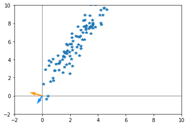

```python
orange = '#FF9A13'
blue = '#1190FF'
plotVectors(eigVecs.T, [orange, blue])
plt.plot(X[:,0], X[:,1], '*')
plt.xlim(-2, 10)
plt.ylim(-2, 10)
plt.show()
```

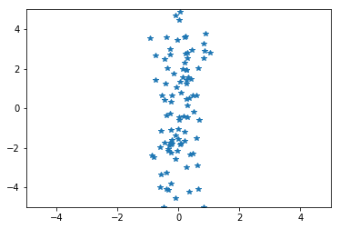

```python
X_new = eigVecs.T.dot(X_center.T)
plt.plot(X_new[0, :], X_new[1, :], '*')
plt.xlim(-5, 5)
plt.ylim(-5, 5)
plt.show()
```

### 7.3) PCA using Sklearn

```python
from sklearn.decomposition import PCA
pca = PCA(n_components=img.shape[1])
new_dim = pca.fit_transform(img)
```

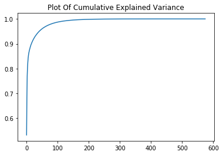

```python
#Choosing Number Of Components
plt.plot(pca.explained_variance_ratio_.cumsum())
plt.title("Plot Of Cumulative Explained Variance")
plt.show()
```

- We will keep around 100 components

```python
pca = PCA(n_components=100)
new_dim = pca.fit_transform(img)
print("Shape of new data = ",new_dim.shape)
print("Reconstructing the Original Data : ")
fin_img = pca.inverse_transform(new_dim)
```

```
Shape of new data =  (575, 100)
Reconstructing the Original Data :
```

```python
f = plt.figure()
f.add_subplot(1,2, 1)
plt.imshow(np.rot90(imgLr,2))
f.add_subplot(1,2, 2)
plt.imshow(np.rot90(imgRr,2))
plt.show(block=True)
```

[output not shown]

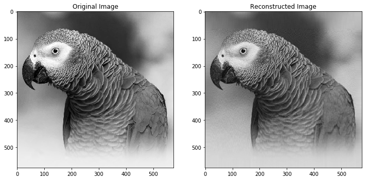

```python
f = plt.figure(figsize=(12, 12))
f.add_subplot(1,2, 1)
plt.imshow(img, cmap='gray')
plt.title("Original Image")
f.add_subplot(1,2, 2)
plt.imshow(fin_img, cmap='gray')
plt.title("Reconstructed Image")
plt.show(block=True)
```

### 7.5) Relationship Between SVD and PCA:

- PCA and SVD are intuitively related.
- In PCA, we compute Eigen Values and Eigen vectors of the Covariance Matrix ie the product of $XX^{T}$ Where $X$ is the Data Matrix.
- Covariance Matrix is Symmetric and also diagonalizable and we can normalize eigen vectors such that they are orthonormal.

$$XX^{T} = WDW^{T}$$

- Now applying SVD to X, we get:

$$X = UDV^{T}$$

- Create Covariance Matrix from this decomposition gives :

$$XX^{T} = (UDV^{T})(UDV^{T})^{T}$$

$$ = (UDV^{T})(VDU^{T})$$

- Since **V** is Orthonormal $V^{T}.V = 1$

- The square root of Eighen Values of $XX^{T}$ are singular values of **X**
- We can use SVD to perform SVD to perform PCA.
- This is better than forming the Covariance Matrix since formation of $XX^{T}$ causes loss of precision.
- Additional Reference : https://arxiv.org/pdf/1404.1100.pdf